# PENDA: PErsoNalized Data Analysis

Performing personalized data analysis with `penda`

Magali Richard, Clémentine Decamps, Florent Chuffart, Daniel Jost

2019-04-29

[figure not shown]

# 1 Introduction

`penda` (**PE**rso**N**alized **D**ifferential **A**nalysis ) is an open-access R package that detects gene deregulation in individual samples compared to as set of reference, control samples. This tutorial aims at providing to non-expert users basic informations and illustrations on how to rune the package.

How to cite: Richard et al. (2019) PenDa, a rank-based method for Personalized Differential Analysis: application to lung cancer, in submission.

# 2 Dataset

The dataset used to illustrated the method corresponds to the transcriptomes of 3000 genes (RNAseq counts, normalized with DESeq2) for 40 normal, control samples and 40 tumorous samples taken from the TCGA study of lung adenocarcinoma [PMID:25079552].

`data_ctrl` is a data matrix containing the normalized counts of each control sample. The rownames of the matrix correspond to the gene_symbol, the colnames indicate the sample ID.

```r
data_ctrl = penda::penda_data_ctrl
```

```
#>       patient_55-6984-11 patient_43-6773-11 patient_55-6978-11
#> AADAC           347.2489           428.5498           442.0555
#> AAMP            965.2342          1528.3221           968.0266
#> ABCA1             0.0000             0.0000             0.0000
#> ABL1           1508.1784          1227.1325          1747.2431
#> ABL2            582.6719           645.4063           488.5088
#> ACACA             0.0000             0.0000             0.0000
#> [1] 3000   40
```

`data_case` is a data matrix containing the normalized counts of each tumor sample. The rownames of the matrix correspond to the gene_symbol, the colnames indicate the sample ID.

```r
data_case = penda::penda_data_case
```

```
#>       patient_69-7764-01 patient_44-3919-01 patient_86-8278-01
#> AADAC           311.2129           374.9473          445.43169
#> AAMP           1466.5906           979.2256         1059.19225
#> ABCA1             0.0000             0.0000            0.00000
#> ABL1           2676.4306          2065.7474         2503.76905
#> ABL2           1167.0482           678.5603         1263.94317
#> ACACA             0.0000             0.0000           12.79693
#> [1] 3000   40
```

# 3 Method

`penda` performs a 3-steps analysis:

1. Data filtering and creation of the dataset
2. Relative gene ordering
3. Differential expression testing

## 3.1 Data filtering

The function `make_dataset` contains three steps to prepare the data for the analysis.

- `detect_na_value` removes rows and columns (ie, genes and samples) of the data matrices that contain more than threshold% (default value = 0.99) of NA (Not Available) value.
- `detect_zero_value` removes genes with very low expression in the majority of samples (controls and cases), ie. genes whose expression is lower than val_min in threshold% of all the samples. By default it uses the function `normalmixEM` to estimate the value of val_minusing all the log2-transformed data but this parameter can also be tuned manually by the user.
- `rank_genes` sorts genes based on the median in controls. This step is essential for the proper functioning of `penda`.

## 3.2 Relative gene ordering

The function `compute_lower_and_higher_lists` computes two matrices of lists L and H based on the filtered control dataset (`data_ctrl_f`).

Each row of the **L** matrix contains a list of at most `s_max` (default value = 50) genes (characterized by their ids) whose expressions are **lower** than that of the gene correspond to the row in at least `threshold_LH` (default value = 99 %) of the control samples.  
Each row of the **H** matrix contains a list of at most `s_max` (default value = 50) genes (characterized by their ids) whose expressions are **higher** than that of the gene correspond to the row in at least `threshold_LH` (default value = 99 %) of the control samples.

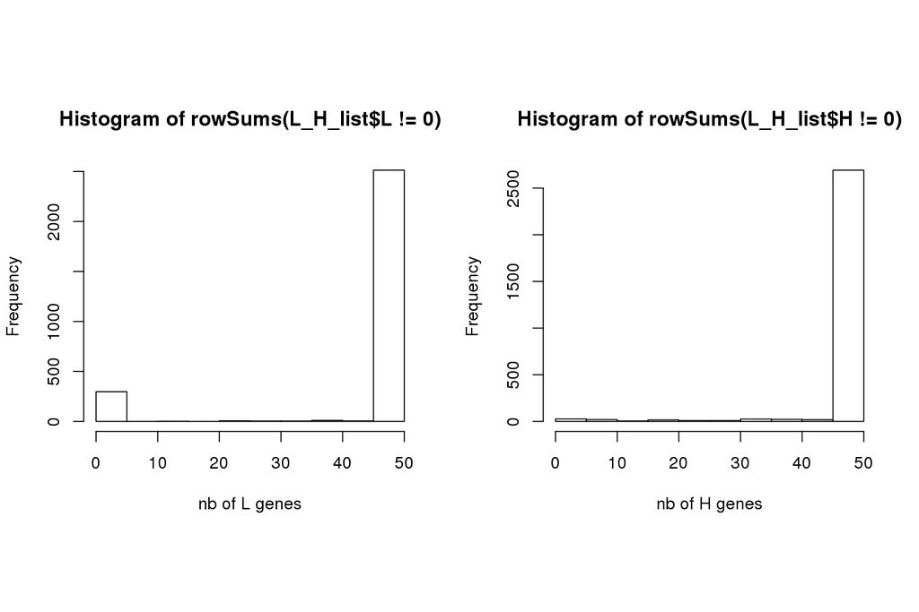

## 3.3 Differential expression testing

The function `penda_test` infer for each gene and for each sample of the `data_case` matrix its deregulation status (up-regulation, down-regulation or no deregulation). This function analyses case samples one by one. It is based on the `L_H_list` and tacks for changes in relative ordering in the sample of interest. If these changes exceed the given `threshold`, the gene of interest is considered as deregulated.

By default, the `threshold` parameter is set to 0.5 but we strongy advise users to use the vignette `vignette simulation` to adjust this parameter to the user-specific data.

Results are in the form of two matrices `$down_genes` and `$up_genes`. Each row corresponds to a gene and each column to a case sample. A TRUE entry in these matrices meands that the corresponding genes is deregulated (down or up-regulated) in the corresponding samples.

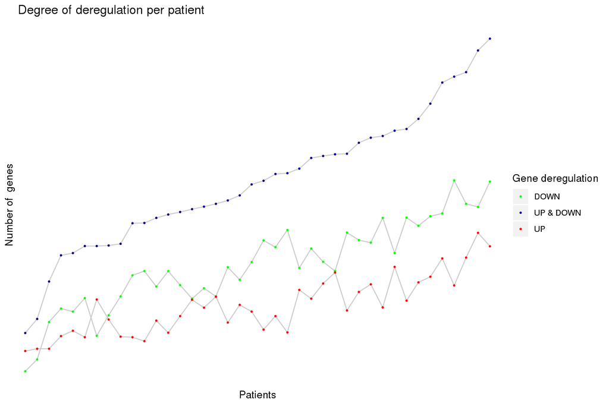

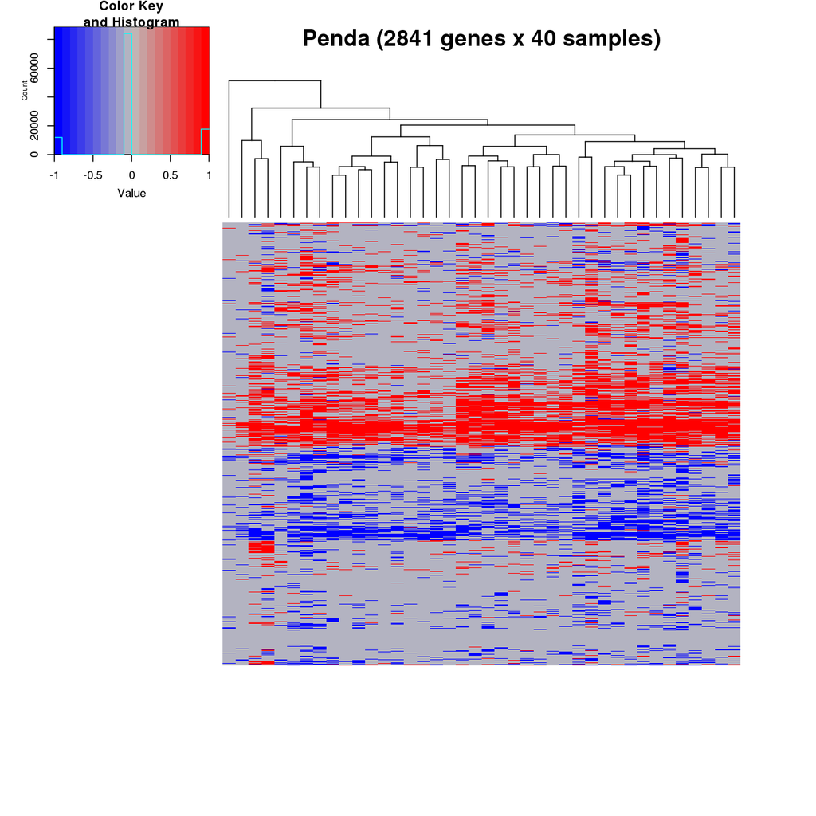

# 4 Material and methods

*This paragraph is automatically generated by the vignette on the parameters used. It can be used to write the “materiel and method” part of your analysis.*

The Penda vignette of the penda package version 1.0 was executed on 3000 genes, using 40 control samples and 40 case samples.

The data set was pretreated as following: 0 genes and 0 patients was removed for NA values, and 159 genes was removed for low value (under the threshold `val_min` of 23.21) in at least 99 % of cases.

40 controls were used to generate L and H lists using the following parameters: threshold LH = 0.99 and s_max = 50.

The penda method was then applied on 40 cases. With the following set of parameters: quantile = 0.08, factor = 1.4 and threshold = 0.5.